# Practical Machine Learning Course Project

Author: Alecia Alianell

### Summary of Project

Using devices such as Jawbone Up, Nike FuelBand, and Fitbit it is now possible to collect a large amount of data about personal activity relatively inexpensively. These type of devices are part of the quantified self movement – a group of enthusiasts who take measurements about themselves regularly to improve their health, to find patterns in their behavior, or because they are tech geeks. One thing that people regularly do is quantify how much of a particular activity they do, but they rarely quantify how well they do it. In this project, your goal will be to use data from accelerometers on the belt, forearm, arm, and dumbell of 6 participants. They were asked to perform barbell lifts correctly and incorrectly in 5 different ways. More information is available from the website here: http://groupware.les.inf.puc-rio.br/har (see the section on the Weight Lifting Exercise Dataset).

The data for the project is available here: [Training](https://d396qusza40orc.cloudfront.net/predmachlearn/pml-training.csv) [Test](https://d396qusza40orc.cloudfront.net/predmachlearn/pml-testing.csv)

### Global Options

We will be using several libraries throughout the project, so they will be loaded here.

```r
require(caret)
require(rpart)
```

```r
require(rpart.plot)
require(rattle)
require(randomForest)
```

#### Set Seed

Here we will set a seed so that the results are reproducible

```r
set.seed(1234)
```

#### Load Data and Partition into Datasets

We need to load the test and training datasets. Also, based on the notes in class, 60% of the data is considered for the training dataset and remaining 40% is considered for the test dataset, whcih can be done using the classe variable. We will also deal with the NA results in the datasets.

```r
# Load data from the web and create train and test datasets
traincsv <- "http://d396qusza40orc.cloudfront.net/predmachlearn/pml-training.csv"
testcsv <- "http://d396qusza40orc.cloudfront.net/predmachlearn/pml-testing.csv"
train <- read.csv(url(traincsv), na.strings=c("NA","#DIV/0!",""))
test <- read.csv(url(testcsv), na.strings=c("NA","#DIV/0!",""))
inTrain <- createDataPartition(y=train$classe, p=0.6, list=FALSE)
train.set <- train[inTrain, ]; test.set <- train[-inTrain, ]
# Check dimensions for number of variables and number of observations
dim(train.set)
```

```
## [1] 11776   160
```

```r
dim(test.set)
```

```
## [1] 7846  160
```

### Preliminary Cleaning

Here we will delete any irrelevant information before performing any analyses.

```r
# Delete columns with all missing values
train.set<-train.set[,colSums(is.na(train.set)) == 0]
test.set <-test.set[,colSums(is.na(test.set)) == 0]

# Some variables are irrelevant to our current project and can be deleted:
train.set<-train.set[,-c(1:7)]
test.set <-test.set[,-c(1:7)]

# Check dimensions for number of variables and number of observations
dim(train.set)
```

```
## [1] 11776    53
```

```r
dim(test.set)
```

```
## [1] 7846   53
```

You can see that we have reduced the number of variables considerably in our cleanup.

### Decision Trees

We will be using the variable classe to see the frequency of each levels in the train.set.

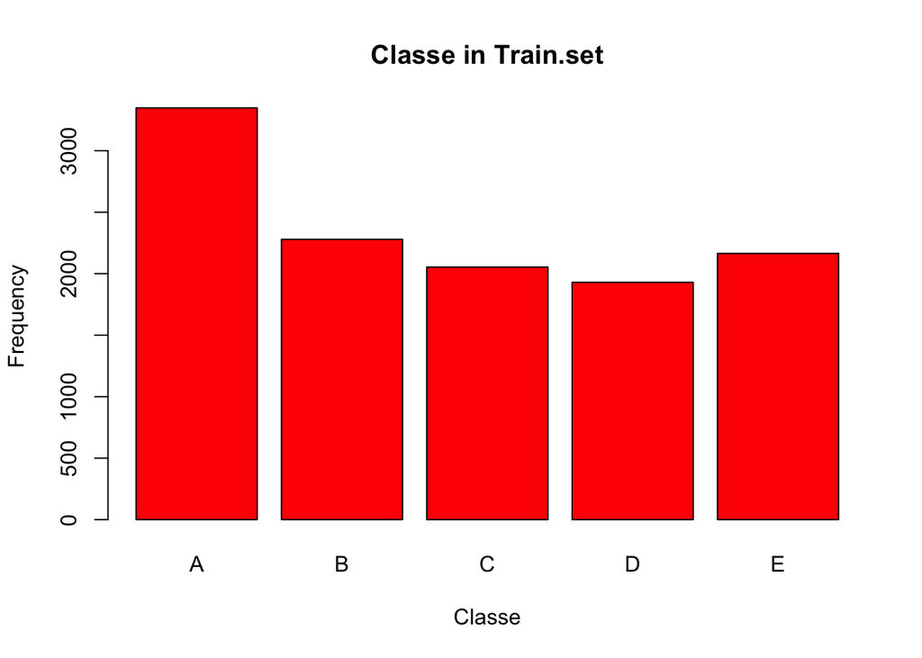

```r
plot(train.set$classe, col="red", main="Classe in Train.set", xlab="Classe", ylab="Frequency")
```

Level A seems to be the most frequent and D the least. Our prediction models should support this.

#### Prediction Model 1 - Decision Tree

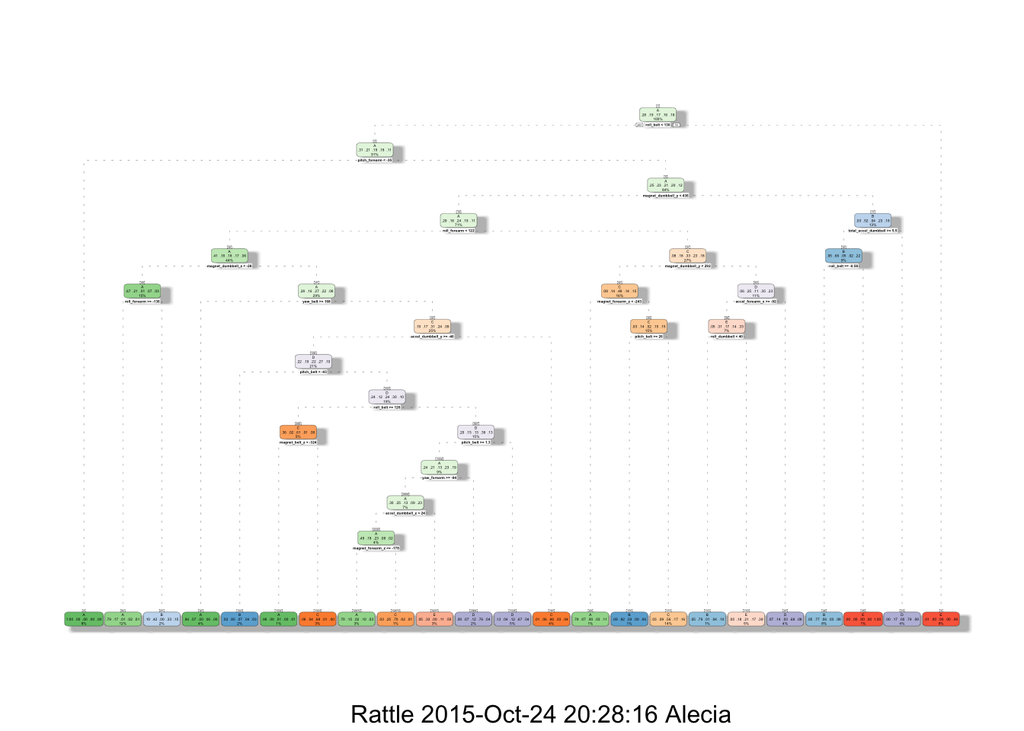

```r
# Prediction Model:
model1 <- rpart(classe ~ ., data=train.set, method="class")
# Plot of Decision Tree
fancyRpartPlot(model1)
```

```r
# Test results on our test.set data:
modelpred1 <- predict(model1, test.set, type = "class")
confusionMatrix(modelpred1, test.set$classe)
```

```
## Confusion Matrix and Statistics
##
##           Reference
## Prediction    A    B    C    D    E
##          A 1980  212   21   72   31
##          B   85  862   72   90   98
##          C   56  153 1086  209  175
##          D   71  101  110  823   89
##          E   40  190   79   92 1049
##
## Overall Statistics
##
##                Accuracy : 0.7392
##                  95% CI : (0.7294, 0.7489)
##     No Information Rate : 0.2845
##     P-Value [Acc > NIR] : < 2.2e-16
##
##                   Kappa : 0.6699
##  Mcnemar's Test P-Value : < 2.2e-16
##
## Statistics by Class:
##
##                      Class: A Class: B Class: C Class: D Class: E
## Sensitivity            0.8871   0.5679   0.7939   0.6400   0.7275
## Specificity            0.9401   0.9455   0.9085   0.9434   0.9374
## Pos Pred Value         0.8549   0.7142   0.6468   0.6893   0.7234
## Neg Pred Value         0.9544   0.9012   0.9543   0.9304   0.9386
## Prevalence             0.2845   0.1935   0.1744   0.1639   0.1838
## Detection Rate         0.2524   0.1099   0.1384   0.1049   0.1337
## Detection Prevalence   0.2952   0.1538   0.2140   0.1522   0.1848
## Balanced Accuracy      0.9136   0.7567   0.8512   0.7917   0.8324
```

#### Prediction Model 2 - Random Forest

```r
model2 <- randomForest(classe ~. , data=train.set, method="class")
# Prediction Model:
modelpred2 <- predict(model2, test.set, type = "class")
# Test results on our test.set data:
confusionMatrix(modelpred2, test.set$classe)
```

```
## Confusion Matrix and Statistics
##
##           Reference
## Prediction    A    B    C    D    E
##          A 2231   12    0    0    0
##          B    0 1501    9    0    0
##          C    0    5 1354   22    2
##          D    1    0    5 1262    2
##          E    0    0    0    2 1438
##
## Overall Statistics
##
##                Accuracy : 0.9924
##                  95% CI : (0.9902, 0.9942)
##     No Information Rate : 0.2845
##     P-Value [Acc > NIR] : < 2.2e-16
##
##                   Kappa : 0.9903
##  Mcnemar's Test P-Value : NA
##
## Statistics by Class:
##
##                      Class: A Class: B Class: C Class: D Class: E
## Sensitivity            0.9996   0.9888   0.9898   0.9813   0.9972
## Specificity            0.9979   0.9986   0.9955   0.9988   0.9997
## Pos Pred Value         0.9947   0.9940   0.9790   0.9937   0.9986
## Neg Pred Value         0.9998   0.9973   0.9978   0.9964   0.9994
## Prevalence             0.2845   0.1935   0.1744   0.1639   0.1838
## Detection Rate         0.2843   0.1913   0.1726   0.1608   0.1833
## Detection Prevalence   0.2859   0.1925   0.1763   0.1619   0.1835
## Balanced Accuracy      0.9987   0.9937   0.9926   0.9901   0.9985
```

## Create Submission Data for Grading

```r
submission <- predict(model2, test, type="class")
submission
```

```
##  1  2  3  4  5  6  7  8  9 10 11 12 13 14 15 16 17 18 19 20
##  B  A  B  A  A  E  D  B  A  A  B  C  B  A  E  E  A  B  B  B
## Levels: A B C D E
```

We will then use the following code to write our submission files:

```r
# Write files for submission
write_files = function(x){
  n = length(x)
  for(i in 1:n){
    filename = paste0("problem_id_",i,".txt")
    write.table(x[i],file=filename,quote=FALSE,row.names=FALSE,col.names=FALSE)
  }
}

write_files(submission)
```